# AIML_ML_Project_full_code_notebookAlllifebank_pawan

## Problem Statement

### Context

AllLife Bank is a US bank that has a growing customer base. The majority of these customers are liability customers (depositors) with varying sizes of deposits. The number of customers who are also borrowers (asset customers) is quite small, and the bank is interested in expanding this base rapidly to bring in more loan business and in the process, earn more through the interest on loans. In particular, the management wants to explore ways of converting its liability customers to personal loan customers (while retaining them as depositors).

A campaign that the bank ran last year for liability customers showed a healthy conversion rate of over 9% success. This has encouraged the retail marketing department to devise campaigns with better target marketing to increase the success ratio.

You as a Data scientist at AllLife bank have to build a model that will help the marketing department to identify the potential customers who have a higher probability of purchasing the loan.

### Objective

To predict whether a liability customer will buy personal loans, to understand which customer attributes are most significant in driving purchases, and identify which segment of customers to target more.

### Data Dictionary

- `ID`: Customer ID
- `Age`: Customer’s age in completed years
- `Experience`: #years of professional experience
- `Income`: Annual income of the customer (in thousand dollars)
- `ZIP Code`: Home Address ZIP code.
- `Family`: the Family size of the customer
- `CCAvg`: Average spending on credit cards per month (in thousand dollars)
- `Education`: Education Level. 1: Undergrad; 2: Graduate;3: Advanced/Professional
- `Mortgage`: Value of house mortgage if any. (in thousand dollars)
- `Personal_Loan`: Did this customer accept the personal loan offered in the last campaign? (0: No, 1: Yes)
- `Securities_Account`: Does the customer have securities account with the bank? (0: No, 1: Yes)
- `CD_Account`: Does the customer have a certificate of deposit (CD) account with the bank? (0: No, 1: Yes)
- `Online`: Do customers use internet banking facilities? (0: No, 1: Yes)
- `CreditCard`: Does the customer use a credit card issued by any other Bank (excluding All life Bank)? (0: No, 1: Yes)

## Importing necessary libraries

```python
# Installing the libraries with the specified version.
!pip install numpy==1.25.2 pandas==1.5.3 matplotlib==3.7.1 seaborn==0.13.1 scikit-learn==1.2.2 sklearn-pandas==2.2.0 -q --user
```

[output not shown]

**Note**:

1. After running the above cell, kindly restart the notebook kernel (for Jupyter Notebook) or runtime (for Google Colab), write the relevant code for the project from the next cell, and run all cells sequentially from the next cell.
2. On executing the above line of code, you might see a warning regarding package dependencies. This error message can be ignored as the above code ensures that all necessary libraries and their dependencies are maintained to successfully execute the code in this notebook.

```python
# import libraries for data manipulation
import numpy as np
import pandas as pd

# import libraries for data visualization
import matplotlib.pyplot as plt
import seaborn as sns

from sklearn.model_selection import train_test_split

# To build model for prediction
from sklearn.tree import DecisionTreeClassifier
from sklearn import tree

# To get diferent metric scores
from sklearn.metrics import (
    f1_score,
    accuracy_score,
    recall_score,
    precision_score,
    confusion_matrix,
)
```

## Loading the dataset

```python
#mount google drive
from google.colab import drive
drive.mount('/content/drive')
#Load the file
df =  pd.read_csv("/content/drive/MyDrive/Loan_Modelling.csv")
```

```python
print("The dataset has {} rows and {} columns.".format(df.shape[0], df.shape[1]))
print (".................................................")
print("Print the top 5 rows of the data set")
df.head(5)
```

```
The dataset has 5000 rows and 14 columns.
.................................................
Print the top 5 rows of the data set
```

|  | ID | Age | Experience | Income | ZIPCode | Family | CCAvg | Education | Mortgage | Personal_Loan | Securities_Account | CD_Account | Online | CreditCard |
| --- | --- | --- | --- | --- | --- | --- | --- | --- | --- | --- | --- | --- | --- | --- |
| 0 | 1 | 25 | 1 | 49 | 91107 | 4 | 1.6 | 1 | 0 | 0 | 1 | 0 | 0 | 0 |
| 1 | 2 | 45 | 19 | 34 | 90089 | 3 | 1.5 | 1 | 0 | 0 | 1 | 0 | 0 | 0 |
| 2 | 3 | 39 | 15 | 11 | 94720 | 1 | 1.0 | 1 | 0 | 0 | 0 | 0 | 0 | 0 |
| 3 | 4 | 35 | 9 | 100 | 94112 | 1 | 2.7 | 2 | 0 | 0 | 0 | 0 | 0 | 0 |
| 4 | 5 | 35 | 8 | 45 | 91330 | 4 | 1.0 | 2 | 0 | 0 | 0 | 0 | 0 | 1 |

```python
df.info()
```

```
<class 'pandas.core.frame.DataFrame'>
RangeIndex: 5000 entries, 0 to 4999
Data columns (total 14 columns):
 #   Column              Non-Null Count  Dtype
---  ------              --------------  -----
 0   ID                  5000 non-null   int64
 1   Age                 5000 non-null   int64
 2   Experience          5000 non-null   int64
 3   Income              5000 non-null   int64
 4   ZIPCode             5000 non-null   int64
 5   Family              5000 non-null   int64
 6   CCAvg               5000 non-null   float64
 7   Education           5000 non-null   int64
 8   Mortgage            5000 non-null   int64
 9   Personal_Loan       5000 non-null   int64
 10  Securities_Account  5000 non-null   int64
 11  CD_Account          5000 non-null   int64
 12  Online              5000 non-null   int64
 13  CreditCard          5000 non-null   int64
dtypes: float64(1), int64(13)
memory usage: 547.0 KB
```

```python
df.isnull().sum()
```

|  | 0 |
| --- | --- |
| ID | 0 |
| Age | 0 |
| Experience | 0 |
| Income | 0 |
| ZIPCode | 0 |
| Family | 0 |
| CCAvg | 0 |
| Education | 0 |
| Mortgage | 0 |
| Personal_Loan | 0 |
| Securities_Account | 0 |
| CD_Account | 0 |
| Online | 0 |
| CreditCard | 0 |

**dtype:** int64

```python
#checking for duplicate values
df.duplicated().sum()
```

```
np.int64(0)
```

## Data Overview

- Observations
- Sanity checks

**Observations: **

- Data has 5000 rows and 14 columns
- All values are numeric.
- Columns do not have type = object hence conversion may not be required

**Sanity checks**

- There is no null values in the data
- There is no duplicate values in the data

## Exploratory Data Analysis.

- EDA is an important part of any project involving data.
- It is important to investigate and understand the data better before building a model with it.
- A few questions have been mentioned below which will help you approach the analysis in the right manner and generate insights from the data.
- A thorough analysis of the data, in addition to the questions mentioned below, should be done.

**Questions**:

1. What is the distribution of mortgage attribute? Are there any noticeable patterns or outliers in the distribution?
2. How many customers have credit cards?
3. What are the attributes that have a strong correlation with the target attribute (personal loan)?
4. How does a customer's interest in purchasing a loan vary with their age?
5. How does a customer's interest in purchasing a loan vary with their education?

```python
df.describe().T
```

|  | count | mean | std | min | 25% | 50% | 75% | max |
| --- | --- | --- | --- | --- | --- | --- | --- | --- |
| ID | 5000.0 | 2500.500000 | 1443.520003 | 1.0 | 1250.75 | 2500.5 | 3750.25 | 5000.0 |
| Age | 5000.0 | 45.338400 | 11.463166 | 23.0 | 35.00 | 45.0 | 55.00 | 67.0 |
| Experience | 5000.0 | 20.104600 | 11.467954 | -3.0 | 10.00 | 20.0 | 30.00 | 43.0 |
| Income | 5000.0 | 73.774200 | 46.033729 | 8.0 | 39.00 | 64.0 | 98.00 | 224.0 |
| ZIPCode | 5000.0 | 93169.257000 | 1759.455086 | 90005.0 | 91911.00 | 93437.0 | 94608.00 | 96651.0 |
| Family | 5000.0 | 2.396400 | 1.147663 | 1.0 | 1.00 | 2.0 | 3.00 | 4.0 |
| CCAvg | 5000.0 | 1.937938 | 1.747659 | 0.0 | 0.70 | 1.5 | 2.50 | 10.0 |
| Education | 5000.0 | 1.881000 | 0.839869 | 1.0 | 1.00 | 2.0 | 3.00 | 3.0 |
| Mortgage | 5000.0 | 56.498800 | 101.713802 | 0.0 | 0.00 | 0.0 | 101.00 | 635.0 |
| Personal_Loan | 5000.0 | 0.096000 | 0.294621 | 0.0 | 0.00 | 0.0 | 0.00 | 1.0 |
| Securities_Account | 5000.0 | 0.104400 | 0.305809 | 0.0 | 0.00 | 0.0 | 0.00 | 1.0 |
| CD_Account | 5000.0 | 0.060400 | 0.238250 | 0.0 | 0.00 | 0.0 | 0.00 | 1.0 |
| Online | 5000.0 | 0.596800 | 0.490589 | 0.0 | 0.00 | 1.0 | 1.00 | 1.0 |
| CreditCard | 5000.0 | 0.294000 | 0.455637 | 0.0 | 0.00 | 0.0 | 1.00 | 1.0 |

```python
#Counting number of users who have credit card
df['CreditCard'].value_counts()[1]
```

```
np.int64(1470)
```

**Observation**

## Univerate analaysis.

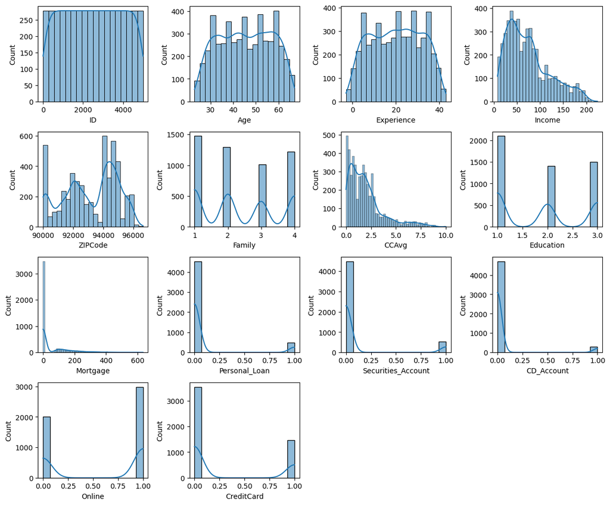

```python
# defining the figure size
plt.figure(figsize=(12, 10))

# plotting the histogram for each numerical feature
for i, feature in enumerate(df.columns):
    plt.subplot(4, 4, i+1)    # assign a subplot in the main plot
    sns.histplot(data=df, x=feature, kde=True)    # plot the histogram

plt.tight_layout();   # to add spacing between plots
```

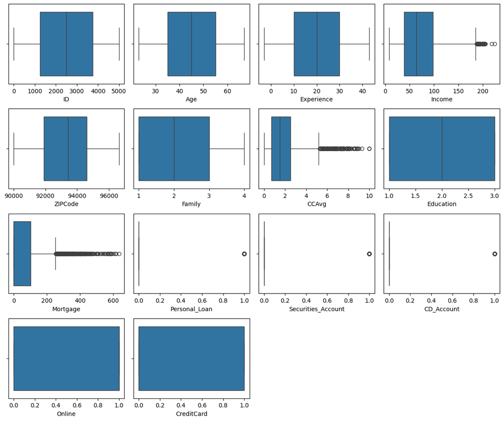

```python
# defining the figure size
plt.figure(figsize=(12, 10))

# plotting the histogram for each numerical feature
for i, feature in enumerate(df.columns):
    plt.subplot(4, 4, i+1)    # assign a subplot in the main plot
    sns.boxplot(data=df, x=feature)    # plot the histogram

plt.tight_layout();   # to add spacing between plots
```

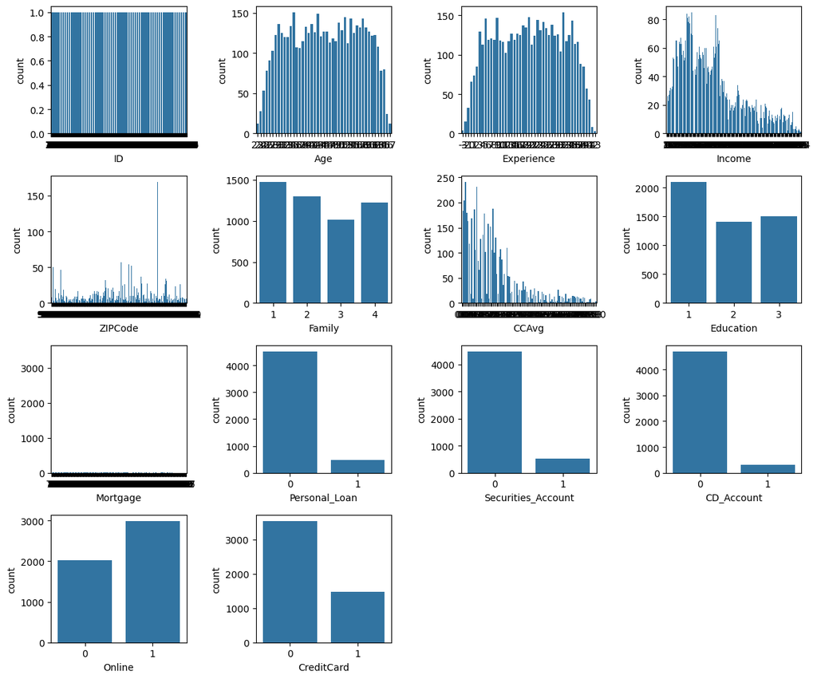

```python
# defining the figure size
plt.figure(figsize=(12, 10))

# plotting the boxplot for each numerical feature
for i, feature in enumerate(df.columns):
    plt.subplot(4, 4, i+1)    # assign a subplot in the main plot
    sns.countplot(data=df, x=feature)    # plot the boxplot

plt.tight_layout();   # to add spacing between plots
```

**Observations:**

- Age and Experience are evenly distributed following somewhat similar distribution.
- Income is right skewed with 75% of the users having income less than 100K.
- There are some outliers with income more than ~180K
- Family size is evenly distributed ranging from 1 to 4
- Average spending on credit card per month (CCAvg) is right skewed data with 75% users spending <2500 per month, with some outliers.
- Users having Personal loan, Securities Account, CD Account are less in number (~10%)
- Users having credit cards are more (~30-35%) compared to other accounts
- Experience seems to have negative value that will need correction later.

***Multivariate Analysis

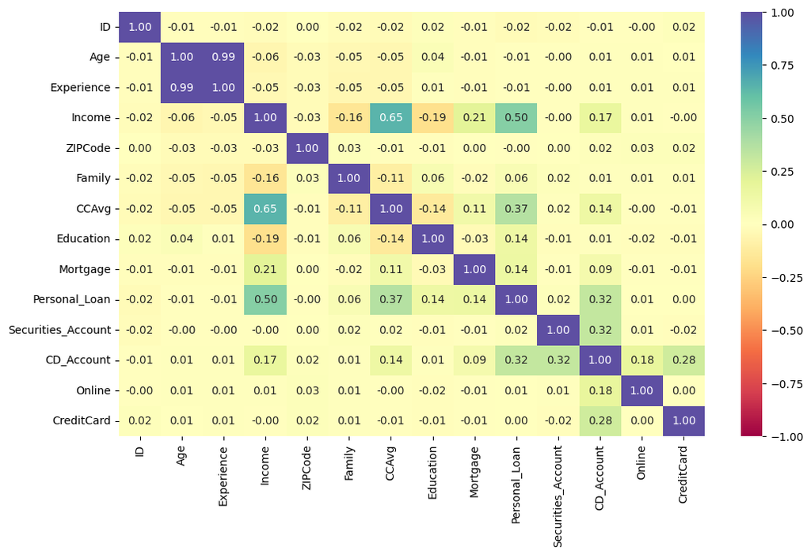

```python
# defining the size of the plot
plt.figure(figsize=(12, 7))

# plotting the heatmap for correlation
sns.heatmap(
    df.corr(),annot=True, vmin=-1, vmax=1, fmt=".2f", cmap="Spectral"
);
```

**Observation**

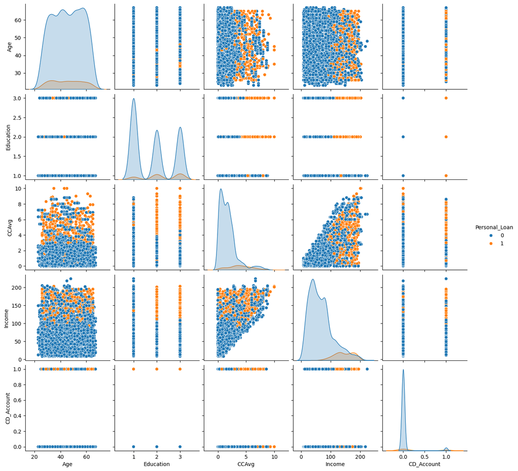

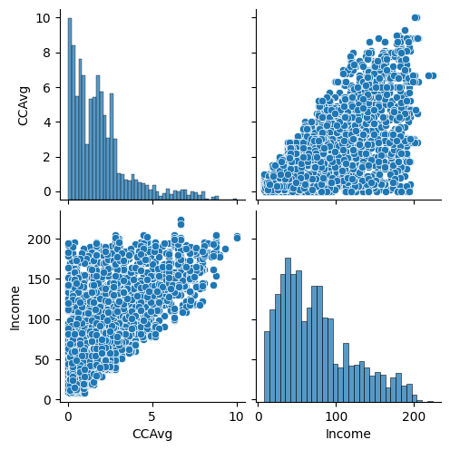

```python
# Analyze numeric fields Age, Education, CCAvg, Income, CD Account, Personal Loan as they show a positive relationship
plt.figure(figsize=(12, 8))

sns.pairplot(data=df[['Age','Education','CCAvg','Income','CD_Account', 'Personal_Loan']], diag_kind='kde',hue='Personal_Loan')

plt.show()
print('                             ')
print('******************************************************************************************************')

# Analyze numeric fields CCAvg and Income using pair plot
sns.pairplot(data=df[['CCAvg','Income']])
plt.show()
print('                             ')
print('*******************************************************************************************************')
```

**Observation**

- Users having CCAvg<3 are more likely to get rejected for personal loan
- Users having income<100k are more likely to get rejected for personal loan
- Users not having any CD account are more likely to get rejected for personal loan
- Users having education level 1 (Undergrad) are more likely to get rejected for personal loan
- CCAvg and Income are positively correlated

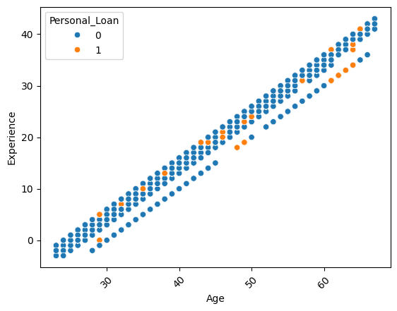

```python
sns.scatterplot(data=df, x='Age', y='Experience', hue='Personal_Loan')
plt.xticks(rotation=45)
plt.show()
```

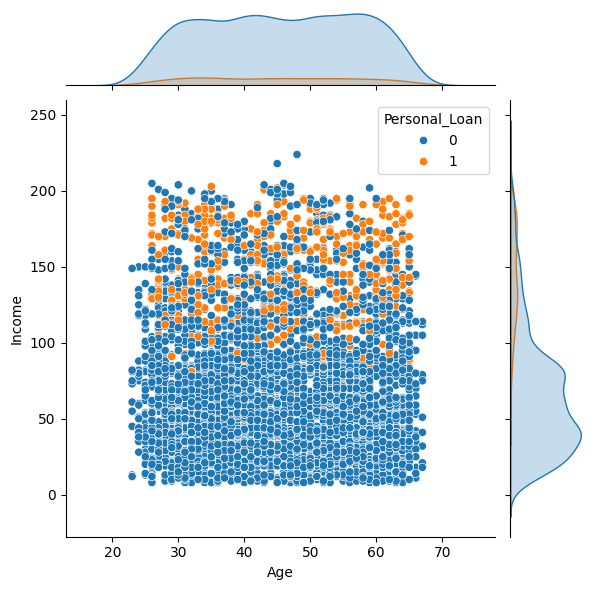

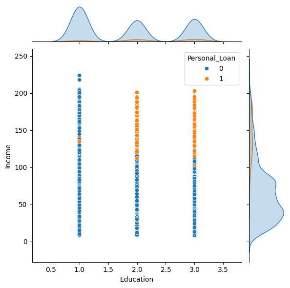

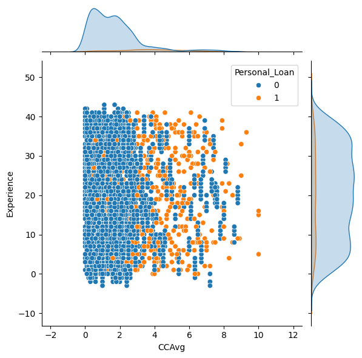

```python
#Create jointplot to see dependencies and relationship between the pairs
sns.jointplot(data=df,x='Age', y='Income', kind="scatter",hue='Personal_Loan')
plt.show()
print('                             ')
print('---------------------------------------------------------')
sns.jointplot(data=df,x='Education', y='Income', kind="scatter", hue='Personal_Loan')
plt.show()
print('                             ')


print('---------------------------------------------------------')
sns.jointplot(data=df,x='CCAvg', y='Experience', kind="scatter",hue='Personal_Loan')
plt.show()
print('                             ')
print('---------------------------------------------------------')
```

**Observation**

- Experience and age have linear correlation with respect to personal loan
- Both follow same distribution
- Fields like Income, CCAvg, Education level can be used for decision tree m modeling
- Users with a income of more than 100K are more likely to have their application approved.

## Data Preprocessing

- Missing value treatment
- Feature engineering (if needed)
- Outlier detection and treatment (if needed)
- Preparing data for modeling
- Any other preprocessing steps (if needed)

```python
df.isnull().sum()
```

|  | 0 |
| --- | --- |
| ID | 0 |
| Age | 0 |
| Experience | 0 |
| Income | 0 |
| ZIPCode | 0 |
| Family | 0 |
| CCAvg | 0 |
| Education | 0 |
| Mortgage | 0 |
| Personal_Loan | 0 |
| Securities_Account | 0 |
| CD_Account | 0 |
| Online | 0 |
| CreditCard | 0 |

**dtype:** int64

```python
df.duplicated().sum()
```

```
np.int64(0)
```

```python
# chdcking experience
df['Experience'].unique()
```

```
array([ 1, 19, 15,  9,  8, 13, 27, 24, 10, 39,  5, 23, 32, 41, 30, 14, 18,
       21, 28, 31, 11, 16, 20, 35,  6, 25,  7, 12, 26, 37, 17,  2, 36, 29,
        3, 22, -1, 34,  0, 38, 40, 33,  4, -2, 42, -3, 43])
```

```python
data = df.copy()
# Correcting the experience values using a dictionary in a single call
data['Experience'] = data['Experience'].replace({-1: 1, -2: 2, -3: 3})
```

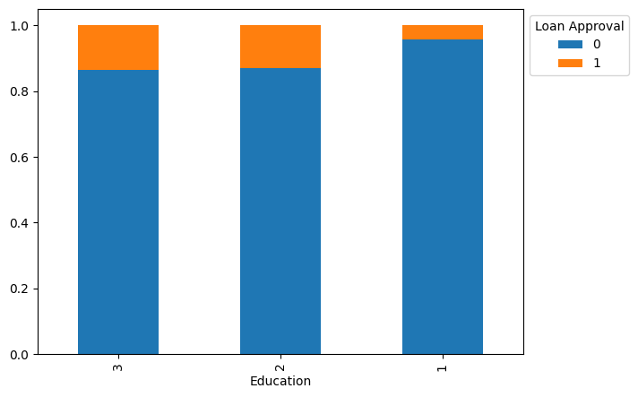

```python
tab = pd.crosstab(
    data['Education'],
    data['Personal_Loan'],
    normalize='index'    # normalizing by dividing each row by its row total
).sort_values(by='Education', ascending=False)    # sorting the resulting crosstab


# Plot the stacked bar chart
tab.plot(kind='bar', stacked=True, figsize=(7, 5))    # creating a stacked bar chart from the normalized crosstab
plt.xlabel('Education')
plt.legend(loc='upper left', bbox_to_anchor=(1, 1), title='Loan Approval');    # adding a legend for the 'Approval' column
```

**Observation**

- Data has neither null or duplicate values
- Experience had negative values which were replaced by postive values
- Data has no null values
- Data has all unique values

### Model Evaluation Criterion

```python
# dropping Experience as Age can be used (Both fields are correlated)
X = data.drop(["Personal_Loan", "Experience"], axis=1)
Y = data["Personal_Loan"]

X = X.astype(float)

# splitting the data in an 70:30 ratio for train and test sets

X_train, X_test, y_train, y_test = train_test_split(
    X, Y, test_size=0.30, random_state=1
)
```

```python
print("Training set rows, columns : ", X_train.shape)
print("Test set rows, columns: ", X_test.shape)
print("Percentage in training set:")
print(y_train.value_counts(normalize=True))
print("Percentage in test set:")
print(y_test.value_counts(normalize=True))
```

```
Training set rows, columns :  (3500, 12)
Test set rows, columns:  (1500, 12)
Percentage in training set:
Personal_Loan
0    0.905429
1    0.094571
Name: proportion, dtype: float64
Percentage in test set:
Personal_Loan
0    0.900667
1    0.099333
Name: proportion, dtype: float64
```

** Observation

### Model Building

```python
# creating an instance of the decision tree model
# random_state sets a seed value and enables reproducibility
# random_state = 1 means repeat the same tree
dtree_model1 = DecisionTreeClassifier(criterion="gini", random_state=1)

# fitting the model to the training data
dtree_model1.fit(X_train, y_train)
```

```
DecisionTreeClassifier(random_state=1)
```

```python
# defining a function to compute different metrics to check performance of a classification model built using sklearn
# define classification model (Decision tree model) function
# Check performance of the model (use sklearn library)
# Calculate different metrics to check performance of classification model
def model_performance_classification(model, predictors, target):
    """
    Function to compute different metrics to check classification model performance

    model: classifier
    predictors: independent variables
    target: dependent variable
    """

    # predicting using the independent variables
    pred = model.predict(predictors)

    acc = accuracy_score(target, pred)  # to compute Accuracy
    recall = recall_score(target, pred)  # to compute Recall
    precision = precision_score(target, pred)  # to compute Precision
    f1 = f1_score(target, pred)  # to compute F1-score

    # creating a dataframe of metrics
    df_perf = pd.DataFrame(
        {"Accuracy": acc, "Recall": recall, "Precision": precision, "F1": f1,},
        index=[0],
    )

    return df_perf
```

```python
def plot_confusion_matrix(model, predictors, target):
    """
    To plot the confusion_matrix with percentages

    model: classifier
    predictors: independent variables
    target: dependent variable
    """
    # Predict the target values using the provided model and predictors
    y_pred = model.predict(predictors)

    # Compute the confusion matrix comparing the true target values with the predicted values
    cm = confusion_matrix(target, y_pred)

    # Create labels for each cell in the confusion matrix with both count and percentage
    labels = np.asarray(
        [
            ["{0:0.0f}".format(item) + "\n{0:.2%}".format(item / cm.flatten().sum())]
            for item in cm.flatten()
        ]
    ).reshape(2, 2)    # reshaping to a matrix

    # Set the figure size for the plot
    plt.figure(figsize=(6, 4))

    # Plot the confusion matrix as a heatmap with the labels
    sns.heatmap(cm, annot=labels, fmt="")

    # Add a label to the y-axis
    plt.ylabel("True label")

    # Add a label to the x-axis
    plt.xlabel("Predicted label")
```

** Observation **

- The focus is to maximize the F1 Score to ensure that we reduce both the chances of approving non-credible applications as well as rejecting credible ones.